# QSM_OEF_Aug18_JCBFM

Ahmed Khalil

13 August 2018

**Methods**  
Linear mixed models were used to investigate:

1. the main effects of hemisphere (contralateral / ischemic) and group (no hypoperfusion / match / large mismatch), as well as their interaction, on the OEF values using the R package “lme4” [1]. The model included varying intercepts for each patient and hemisphere.
2. the relationship between OEF and rCBF in the ischemic hemispheres (with varying intercepts for each patient).
3. the relationship between the distance from the DWI lesion and the OEF value. This included the pattern of hypoperfusion (match vs large mismatch) as a fixed effect (with varying intercepts for each patient).
4. the relationship between the ineraction of NIHSS and time (baseline / follow up) with the OEF ratio (with varying intercepts for each patient).

P-values of the mixed models’ coefficients were calculated using Satterthwaite’s method for approximating degrees-of-freedom (R package “lmerTest” [2]). A visualization of the models was created using the R package “effects” [3]. Marginal and conditional R-squared were calculated using the R package “MuMIn” [4].

*References:*  
[1] Douglas Bates, Martin Maechler, Ben Bolker, Steve Walker (2015). Fitting Linear Mixed-Effects Models Using lme4. Journal of Statistical Software, 67(1), 1-48. doi:10.18637/jss.v067.i01.

[2] Kuznetsova A, Brockhoff PB and Christensen RHB (2017). “lmerTest Package: Tests in Linear Mixed Effects Models.” Journal of Statistical Software, 82(13), pp. 1-26. doi: 10.18637/jss.v082.i13 (URL: http://doi.org/10.18637/jss.v082.i13).

[3] John Fox (2003). Effect Displays in R for Generalised Linear Models. Journal of Statistical Software, 8(15), 1-27. URL http://www.jstatsoft.org/v08/i15/.

[4] Kamil Barton (2018). MuMIn: Multi-Model Inference. R package version 1.42.1. https://CRAN.R-project.org/package=MuMIn

# Model 1

```
## Type III Analysis of Variance Table with Satterthwaite's method
##                     Sum Sq   Mean Sq NumDF  DenDF F value   Pr(>F)
## Group            0.0156603 0.0078302     2 16.249  3.1843 0.068102 .
## Hemisphere       0.0097982 0.0097982     1 62.004  3.9846 0.050313 .
## Group:Hemisphere 0.0254115 0.0127058     2 61.825  5.1671 0.008413 **
## ---
## Signif. codes:  0 '***' 0.001 '**' 0.01 '*' 0.05 '.' 0.1 ' ' 1
```

```
## Linear mixed model fit by REML. t-tests use Satterthwaite's method [
## lmerModLmerTest]
## Formula: OEF ~ Group * Hemisphere + (Hemisphere | Patient)
##    Data: OEF_data
##
## REML criterion at convergence: -543.7
##
## Scaled residuals:
##     Min      1Q  Median      3Q     Max
## -1.9599 -0.7045 -0.1051  0.6206  3.6182
##
## Random effects:
##  Groups   Name               Variance  Std.Dev. Corr
##  Patient  (Intercept)        8.289e-04 0.028790
##           Hemisphereischemic 8.644e-05 0.009297 1.00
##  Residual                    2.459e-03 0.049588
## Number of obs: 193, groups:  Patient, 20
##
## Fixed effects:
##                                         Estimate Std. Error        df
## (Intercept)                             0.238671   0.013840 15.920000
## GroupMatch                              0.060826   0.020466 16.180000
## GroupLarge mismatch                     0.013611   0.019844 16.530000
## Hemisphereischemic                      0.008688   0.012275 57.210000
## GroupMatch:Hemisphereischemic          -0.020291   0.018544 61.140000
## GroupLarge mismatch:Hemisphereischemic  0.039591   0.017980 60.600000
##                                        t value Pr(>|t|)
## (Intercept)                             17.246    1e-11 ***
## GroupMatch                               2.972   0.0089 **
## GroupLarge mismatch                      0.686   0.5023
## Hemisphereischemic                       0.708   0.4819
## GroupMatch:Hemisphereischemic           -1.094   0.2782
## GroupLarge mismatch:Hemisphereischemic   2.202   0.0315 *
## ---
## Signif. codes:  0 '***' 0.001 '**' 0.01 '*' 0.05 '.' 0.1 ' ' 1
##
## Correlation of Fixed Effects:
##             (Intr) GrpMtc GrpLrm Hmsphr GrpM:H
## GroupMatch  -0.676
## GrpLrgmsmtc -0.697  0.472
## Hmsphrschmc -0.202  0.137  0.141
## GrpMtch:Hms  0.134 -0.208 -0.093 -0.662
## GrpLmsmtc:H  0.138 -0.093 -0.211 -0.683  0.452
```

```
##            R2m       R2c
## [1,] 0.1548291 0.4243087
```

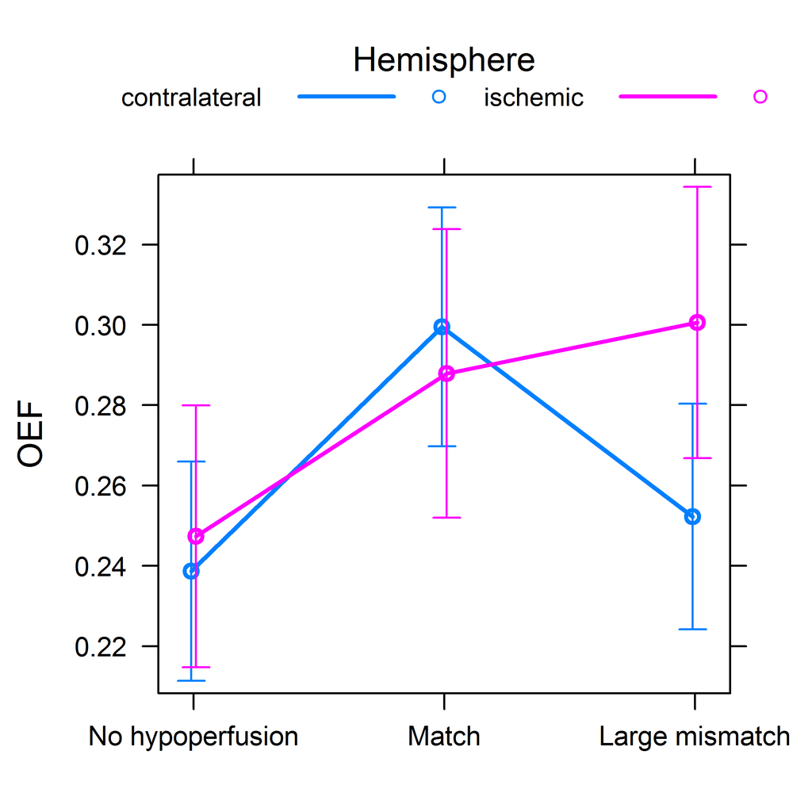

# Model 2

```
## Type III Analysis of Variance Table with Satterthwaite's method
##              Sum Sq  Mean Sq NumDF  DenDF F value   Pr(>F)
## rCBF       0.016723 0.016723     1 68.387  5.7803 0.018921 *
## Group      0.034453 0.017226     2 52.986  5.9544 0.004649 **
## rCBF:Group 0.034584 0.017292     2 68.478  5.9770 0.004050 **
## ---
## Signif. codes:  0 '***' 0.001 '**' 0.01 '*' 0.05 '.' 0.1 ' ' 1
```

```
## Linear mixed model fit by REML. t-tests use Satterthwaite's method [
## lmerModLmerTest]
## Formula: OEF ~ rCBF * Group + (1 | Patient)
##    Data: OEF_CBF_data
##
## REML criterion at convergence: -232.3
##
## Scaled residuals:
##      Min       1Q   Median       3Q      Max
## -1.57294 -0.64749 -0.03489  0.49074  2.97039
##
## Random effects:
##  Groups   Name        Variance Std.Dev.
##  Patient  (Intercept) 0.001300 0.03606
##  Residual             0.002893 0.05379
## Number of obs: 93, groups:  Patient, 21
##
## Fixed effects:
##                     Estimate Std. Error        df t value Pr(>|t|)
## (Intercept)         0.252896   0.034280 66.450000   7.377 3.32e-10 ***
## rCBF               -0.001002   0.041487 84.250000  -0.024  0.98078
## Groupmatch          0.044011   0.054414 50.510000   0.809  0.42241
## Grouplarge_MM       0.163640   0.048630 61.220000   3.365  0.00133 **
## rCBF:Groupmatch     0.010411   0.068247 63.030000   0.153  0.87924
## rCBF:Grouplarge_MM -0.218701   0.069191 79.520000  -3.161  0.00223 **
## ---
## Signif. codes:  0 '***' 0.001 '**' 0.01 '*' 0.05 '.' 0.1 ' ' 1
##
## Correlation of Fixed Effects:
##             (Intr) rCBF   Grpmtc Grp_MM rCBF:Gr
## rCBF        -0.897
## Groupmatch  -0.630  0.565
## Grouplrg_MM -0.705  0.633  0.444
## rCBF:Grpmtc  0.546 -0.608 -0.886 -0.385
## rCBF:Grp_MM  0.538 -0.600 -0.339 -0.872  0.365
```

```
##            R2m       R2c
## [1,] 0.2473337 0.4807009
```

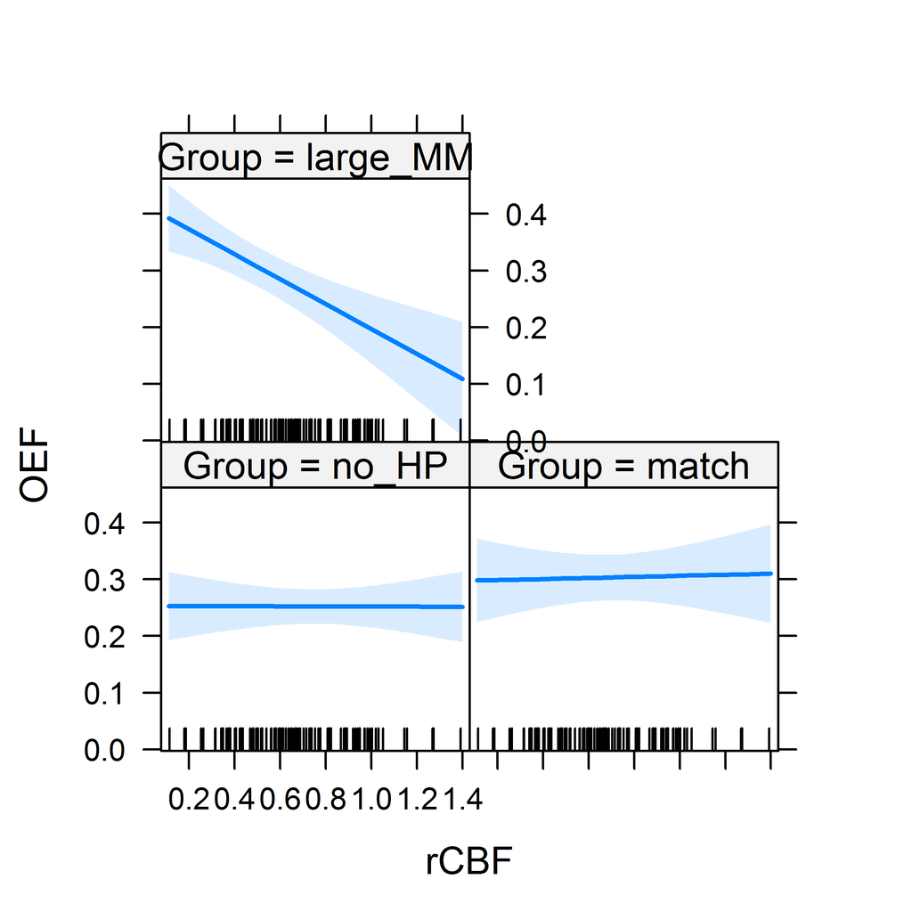

```
## Type III Analysis of Variance Table with Satterthwaite's method
##             Sum Sq Mean Sq NumDF  DenDF F value   Pr(>F)
## rCBF       0.24646 0.24646     1 49.402  5.5524 0.022465 *
## Group      0.57307 0.28653     2 43.370  6.4553 0.003515 **
## rCBF:Group 0.38034 0.19017     2 49.019  4.2843 0.019284 *
## ---
## Signif. codes:  0 '***' 0.001 '**' 0.01 '*' 0.05 '.' 0.1 ' ' 1
```

```
## Linear mixed model fit by REML. t-tests use Satterthwaite's method [
## lmerModLmerTest]
## Formula: rOEF ~ rCBF * Group + (1 | Patient)
##    Data: OEF_CBF_data
##
## REML criterion at convergence: -7.5
##
## Scaled residuals:
##      Min       1Q   Median       3Q      Max
## -2.00030 -0.71796  0.04537  0.56531  2.36559
##
## Random effects:
##  Groups   Name        Variance Std.Dev.
##  Patient  (Intercept) 0.00332  0.05762
##  Residual             0.04439  0.21068
## Number of obs: 93, groups:  Patient, 21
##
## Fixed effects:
##                    Estimate Std. Error       df t value Pr(>|t|)
## (Intercept)         1.06969    0.11088 42.21000   9.648 3.08e-12 ***
## rCBF               -0.02917    0.13878 44.41000  -0.210  0.83445
## Groupmatch         -0.04681    0.17168 44.87000  -0.273  0.78639
## Grouplarge_MM       0.47583    0.15570 41.45000   3.056  0.00391 **
## rCBF:Groupmatch     0.02495    0.22011 47.04000   0.113  0.91022
## rCBF:Grouplarge_MM -0.61299    0.23023 49.70000  -2.662  0.01042 *
## ---
## Signif. codes:  0 '***' 0.001 '**' 0.01 '*' 0.05 '.' 0.1 ' ' 1
##
## Correlation of Fixed Effects:
##             (Intr) rCBF   Grpmtc Grp_MM rCBF:Gr
## rCBF        -0.941
## Groupmatch  -0.646  0.608
## Grouplrg_MM -0.712  0.670  0.460
## rCBF:Grpmtc  0.593 -0.630 -0.915 -0.422
## rCBF:Grp_MM  0.567 -0.603 -0.366 -0.917  0.380
```

```
##            R2m       R2c
## [1,] 0.2096018 0.2646026
```

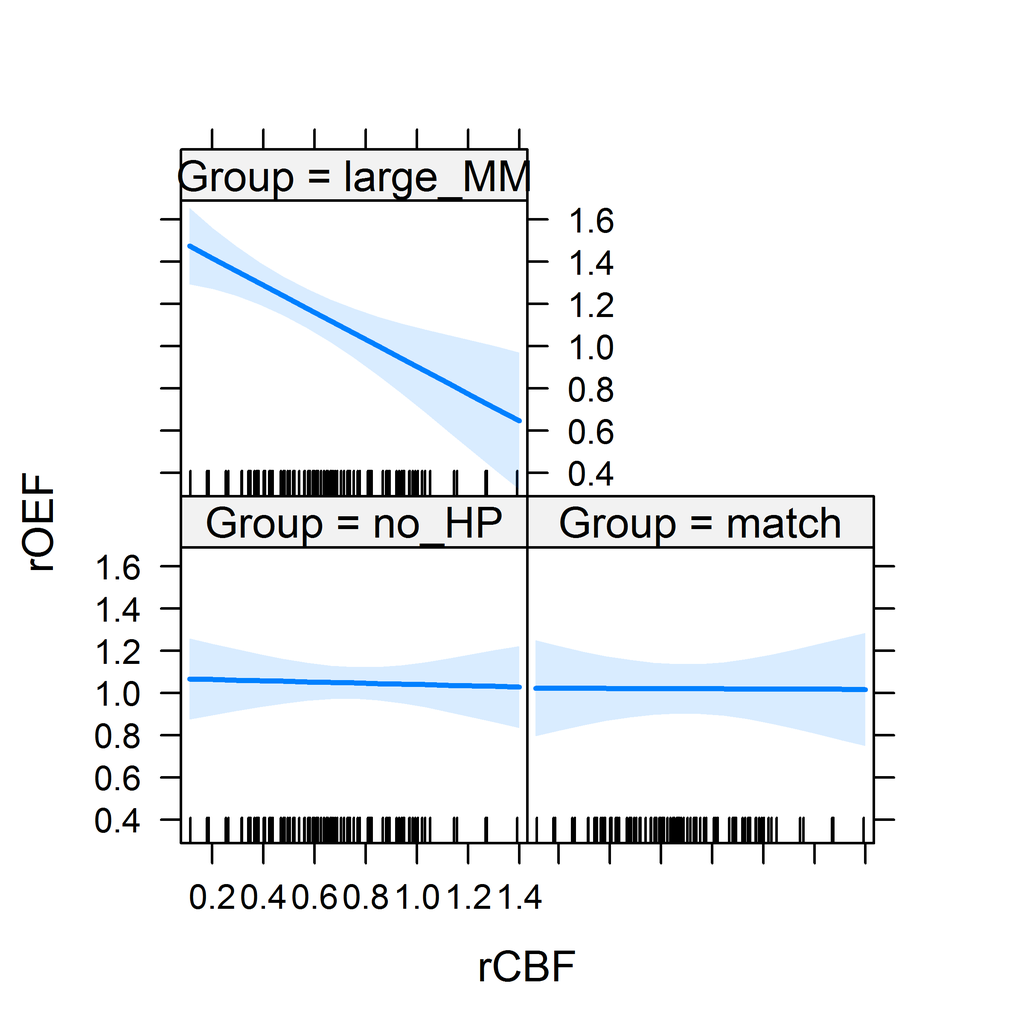

# Model 3

```
## Type III Analysis of Variance Table with Satterthwaite's method
##                  Sum Sq  Mean Sq NumDF   DenDF F value    Pr(>F)
## Distance       0.093356 0.093356     1 195.902 24.8405 1.366e-06 ***
## Group          0.008243 0.008243     1   2.173  2.1932    0.2673
## Distance:Group 0.077447 0.077447     1 195.902 20.6074 9.829e-06 ***
## ---
## Signif. codes:  0 '***' 0.001 '**' 0.01 '*' 0.05 '.' 0.1 ' ' 1
```

```
## Linear mixed model fit by REML. t-tests use Satterthwaite's method [
## lmerModLmerTest]
## Formula: OEF ~ Distance * Group + (1 | Patient)
##    Data: OEF_dist_data
##
## REML criterion at convergence: -506.4
##
## Scaled residuals:
##     Min      1Q  Median      3Q     Max
## -3.4895 -0.6610 -0.0892  0.5037  4.4086
##
## Random effects:
##  Groups   Name        Variance Std.Dev.
##  Patient  (Intercept) 0.004278 0.0654
##  Residual             0.003758 0.0613
## Number of obs: 201, groups:  Patient, 4
##
## Fixed effects:
##                                Estimate Std. Error         df t value
## (Intercept)                   2.721e-01  4.756e-02  2.140e+00   5.721
## Distance                     -2.752e-04  6.306e-04  1.954e+02  -0.436
## GroupLarge mismatch           9.996e-02  6.750e-02  2.170e+00   1.481
## Distance:GroupLarge mismatch -5.621e-03  1.238e-03  1.959e+02  -4.540
##                              Pr(>|t|)
## (Intercept)                    0.0249 *
## Distance                       0.6630
## GroupLarge mismatch            0.2673
## Distance:GroupLarge mismatch 9.83e-06 ***
## ---
## Signif. codes:  0 '***' 0.001 '**' 0.01 '*' 0.05 '.' 0.1 ' ' 1
##
## Correlation of Fixed Effects:
##             (Intr) Distnc GrpLrm
## Distance    -0.197
## GrpLrgmsmtc -0.705  0.138
## Dstnc:GrpLm  0.100 -0.509 -0.208
```

```
##            R2m       R2c
## [1,] 0.1252987 0.5909242
```

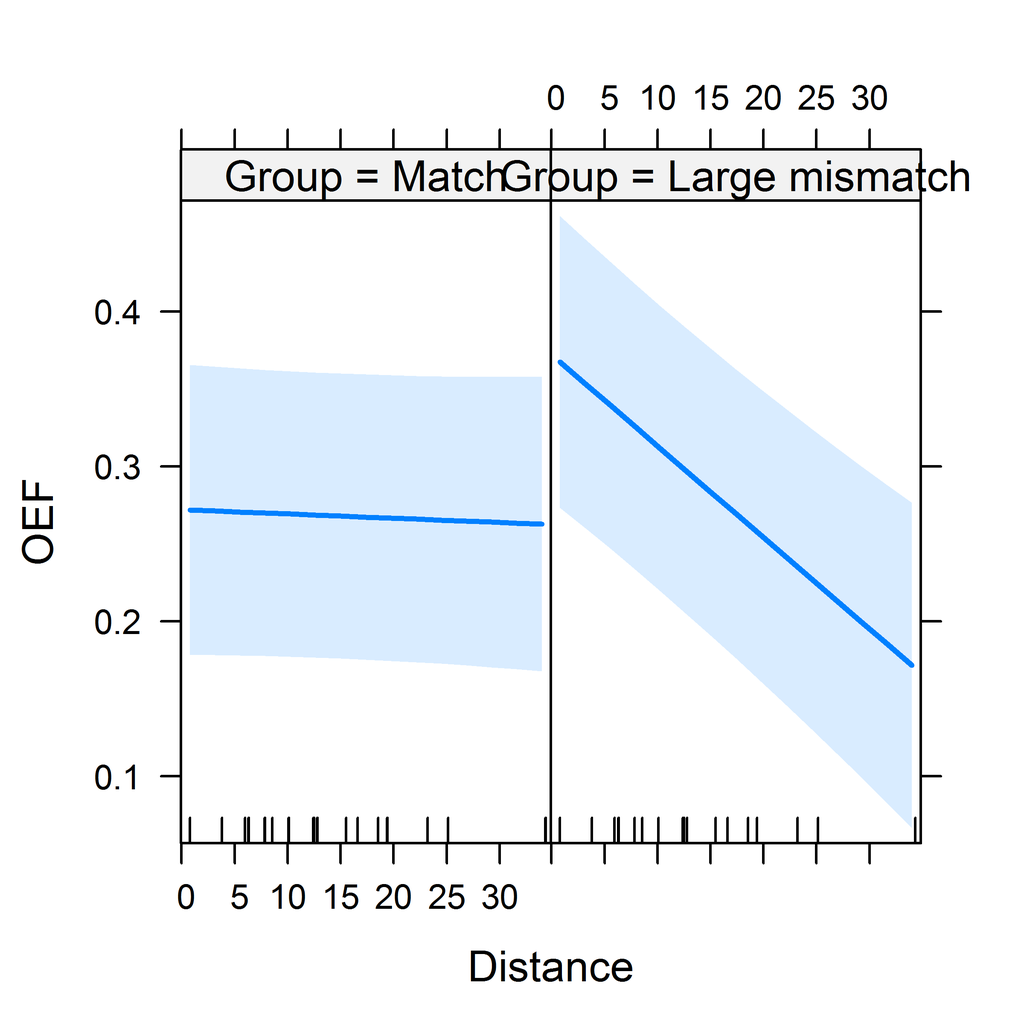

# Model 4

```
## Type III Analysis of Variance Table with Satterthwaite's method
##                   Sum Sq  Mean Sq NumDF   DenDF F value  Pr(>F)
## Timepoint       0.002192 0.002192     1  7.9101  0.2681 0.61878
## NIHSS           0.006330 0.006330     1 10.1106  0.7743 0.39933
## Timepoint:NIHSS 0.052052 0.052052     1  7.4905  6.3671 0.03751 *
## ---
## Signif. codes:  0 '***' 0.001 '**' 0.01 '*' 0.05 '.' 0.1 ' ' 1
```

```
## Linear mixed model fit by REML. t-tests use Satterthwaite's method [
## lmerModLmerTest]
## Formula: OEF_ratio ~ Timepoint * NIHSS + (1 | Patient)
##    Data: OEF_fu_data
##
## REML criterion at convergence: -7.2
##
## Scaled residuals:
##      Min       1Q   Median       3Q      Max
## -1.51175 -0.43962 -0.04413  0.46041  1.33630
##
## Random effects:
##  Groups   Name        Variance Std.Dev.
##  Patient  (Intercept) 0.005208 0.07216
##  Residual             0.008175 0.09042
## Number of obs: 18, groups:  Patient, 9
##
## Fixed effects:
##                    Estimate Std. Error        df t value Pr(>|t|)
## (Intercept)        1.133977   0.054383 13.291000  20.852 1.53e-11 ***
## TimepointFU       -0.029308   0.056604  7.910000  -0.518   0.6188
## NIHSS              0.019584   0.009082 13.879000   2.156   0.0491 *
## TimepointFU:NIHSS -0.026347   0.010441  7.490000  -2.523   0.0375 *
## ---
## Signif. codes:  0 '***' 0.001 '**' 0.01 '*' 0.05 '.' 0.1 ' ' 1
##
## Correlation of Fixed Effects:
##             (Intr) TmpnFU NIHSS
## TimepointFU -0.690
## NIHSS       -0.705  0.560
## TmpFU:NIHSS  0.421 -0.612 -0.598
```

```
##            R2m       R2c
## [1,] 0.3805675 0.6216093
```

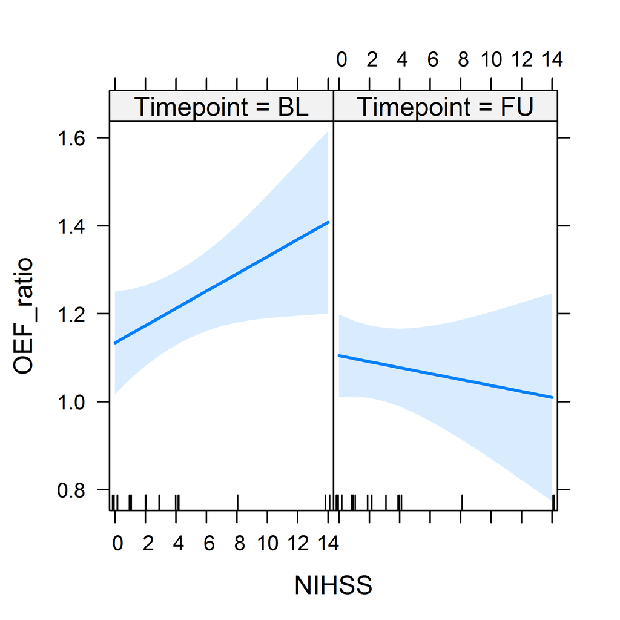

**Results**  
There was no statistically significant main effect of either group (F = 3.18, p = 0.07) or hemisphere (F= 3.98, p = 0.05) on OEF values. The marginal R-squared (fixed effects only) was 0.15 and the conditional R-squared (fixed + random effects) was 0.42. There was a statistically significant interaction between group and hemisphere (F = 5.17, p = 0.008), with the difference in OEF between hemispheres being most prominent in patients with large mismatch (b = 0.04, standard error = 0.018, t = 2.2, p = 0.0315).

There was a statistically significant interaction between the distance from the DWI lesion to the vein and the perfusion pattern (match / large mismatch) on the OEF values (b = -0.0056, standard error = 0.0012, t = -4.54, p < 0.0001). The marginal R-squared (fixed effects only) was 0.13 and the conditional R-squared (fixed + random effects) was 0.59.